# Jiayi Yang STAT 6210 - Final Project

Final model with members 4th

```r
finalLm <- lm(rating ~. -genre_Vampire-genre_Yaoi-genre_Yuri-genre_Space-`genre_Shoujo Ai`-genre_Samurai-`genre_Martial Arts`-genre_Mecha-genre_Harem-genre_Demons-genre_Game-genre_Cars-members+poly(members,4), data=aniMat)
summary(finalLm)
```

```
Call:
lm(formula = rating ~ . - genre_Vampire - genre_Yaoi - genre_Yuri -
    genre_Space - `genre_Shoujo Ai` - genre_Samurai - `genre_Martial Arts` -
    genre_Mecha - genre_Harem - genre_Demons - genre_Game - genre_Cars -
    members + poly(members, 4), data = aniMat)

Residuals:
    Min      1Q  Median      3Q     Max
-4.4874 -0.4340  0.0592  0.5116  4.1127

Coefficients:
                        Estimate Std. Error t value Pr(>|t|)
(Intercept)            5.928e+00  2.832e-02 209.316  < 2e-16 ***
type                   2.363e-02  4.810e-03   4.913 9.10e-07 ***
episodes               1.513e-03  1.541e-04   9.818  < 2e-16 ***
genre_Action           4.091e-02  2.001e-02   2.044 0.040953 *
genre_Adventure        1.964e-01  2.035e-02   9.651  < 2e-16 ***
genre_Comedy           8.251e-02  1.726e-02   4.780 1.78e-06 ***
genre_Dementia        -8.786e-01  5.386e-02 -16.314  < 2e-16 ***
genre_Drama            3.843e-01  2.110e-02  18.216  < 2e-16 ***
genre_Ecchi           -1.702e-01  3.437e-02  -4.953 7.39e-07 ***
genre_Fantasy          1.468e-01  2.067e-02   7.102 1.30e-12 ***
genre_Hentai           1.691e-01  2.890e-02   5.850 5.04e-09 ***
genre_Historical       2.952e-01  3.015e-02   9.791  < 2e-16 ***
genre_Horror          -1.913e-01  4.452e-02  -4.296 1.75e-05 ***
genre_Josei            4.076e-01  1.110e-01   3.671 0.000243 ***
genre_Kids            -3.642e-02  2.316e-02  -1.573 0.115764
genre_Magic            9.084e-02  3.187e-02   2.850 0.004378 **
genre_Military         2.724e-01  4.147e-02   6.569 5.26e-11 ***
genre_Music           -1.219e-01  3.021e-02  -4.037 5.46e-05 ***
genre_Mystery          3.250e-01  3.991e-02   8.143 4.23e-16 ***
genre_Parody           7.062e-02  4.130e-02   1.710 0.087267 .
genre_Police           4.203e-01  5.954e-02   7.059 1.77e-12 ***
genre_Psychological    9.819e-02  5.659e-02   1.735 0.082760 .
genre_Romance          5.505e-02  2.494e-02   2.207 0.027315 *
genre_School           1.695e-01  2.653e-02   6.389 1.73e-10 ***
`genre_Sci-Fi`         1.367e-01  2.153e-02   6.350 2.23e-10 ***
genre_Seinen           2.078e-01  3.632e-02   5.722 1.08e-08 ***
genre_Shoujo           2.464e-01  3.568e-02   6.904 5.30e-12 ***
genre_Shounen          3.628e-01  2.324e-02  15.612  < 2e-16 ***
`genre_Shounen Ai`     1.579e-01  1.017e-01   1.553 0.120525
`genre_Slice of Life`  1.911e-01  2.586e-02   7.388 1.59e-13 ***
genre_Sports           2.642e-01  3.704e-02   7.132 1.05e-12 ***
`genre_Super Power`    4.786e-02  3.962e-02   1.208 0.227102
genre_Supernatural     6.950e-02  2.849e-02   2.440 0.014714 *
genre_Thriller         1.367e-01  8.992e-02   1.521 0.128366
poly(members, 4)1      3.463e+01  8.937e-01  38.753  < 2e-16 ***
poly(members, 4)2     -2.254e+01  8.341e-01 -27.018  < 2e-16 ***
poly(members, 4)3      1.653e+01  8.161e-01  20.250  < 2e-16 ***
poly(members, 4)4     -1.469e+01  8.088e-01 -18.161  < 2e-16 ***
---
Signif. codes:  0 *** 0.001 ** 0.01 * 0.05 . 0.1   1

Residual standard error: 0.7889 on 12026 degrees of freedom
Multiple R-squared:  0.4115,    Adjusted R-squared:  0.4097
F-statistic: 227.3 on 37 and 12026 DF,  p-value: < 2.2e-16
```

```r
finalLm2 <- lm(rating~genre_Supernatural+genre_SliceofLife+genre_Sports+genre_Shoujo+
genre_Shounen+genre_Romance+genre_School+genre_SciFi+genre_Seinen+genre_Music+genre_Mystery+
genre_Police+genre_Psychological+genre_Kids+genre_Military+genre_Hentai+genre_Historical+genre_Horror+genre_Josei+
genre_Dementia+genre_Drama+genre_Fantasy+type+episodes+genre_Action+genre_Adventure+genre_Comedy+poly(members,4), data=aniMat)
summary(finalLm2)
```

```
Call:
lm(formula = rating ~ genre_Supernatural + genre_SliceofLife +
    genre_Sports + genre_Shoujo + genre_Shounen + genre_Romance +
    genre_School + genre_SciFi + genre_Seinen + genre_Music +
    genre_Mystery + genre_Police + genre_Psychological + genre_Kids +
    genre_Military + genre_Hentai + genre_Historical + genre_Horror +
    genre_Josei + genre_Dementia + genre_Drama + genre_Fantasy +
    type + episodes + genre_Action + genre_Adventure + genre_Comedy +
    poly(members, 4), data = aniMat)

Residuals:
    Min      1Q  Median      3Q     Max
-4.4884 -0.4367  0.0603  0.5116  4.1824

Coefficients:
                      Estimate Std. Error t value Pr(>|t|)
(Intercept)          5.932e+00  2.816e-02 210.625  < 2e-16 ***
genre_Supernatural   7.323e-02  2.844e-02   2.575 0.010026 *
genre_SliceofLife    1.922e-01  2.567e-02   7.487 7.53e-14 ***
genre_Sports         2.601e-01  3.697e-02   7.034 2.11e-12 ***
genre_Shoujo         2.809e-01  3.488e-02   8.055 8.72e-16 ***
genre_Shounen        3.616e-01  2.320e-02  15.585  < 2e-16 ***
genre_Romance        3.980e-02  2.463e-02   1.616 0.106177
genre_School         1.549e-01  2.643e-02   5.862 4.69e-09 ***
genre_SciFi          1.353e-01  2.154e-02   6.283 3.44e-10 ***
genre_Seinen         1.960e-01  3.628e-02   5.403 6.69e-08 ***
genre_Music         -1.228e-01  3.019e-02  -4.067 4.80e-05 ***
genre_Mystery        3.414e-01  3.951e-02   8.642  < 2e-16 ***
genre_Police         4.131e-01  5.952e-02   6.940 4.12e-12 ***
genre_Psychological  1.149e-01  5.596e-02   2.054 0.040006 *
genre_Kids          -3.916e-02  2.309e-02  -1.696 0.089878 .
genre_Military       2.668e-01  4.145e-02   6.437 1.26e-10 ***
genre_Hentai         1.695e-01  2.879e-02   5.888 4.02e-09 ***
genre_Historical     2.960e-01  3.012e-02   9.828  < 2e-16 ***
genre_Horror        -1.965e-01  4.454e-02  -4.412 1.03e-05 ***
genre_Josei          4.096e-01  1.111e-01   3.686 0.000229 ***
genre_Dementia      -8.819e-01  5.389e-02 -16.366  < 2e-16 ***
genre_Drama          3.905e-01  2.103e-02  18.570  < 2e-16 ***
genre_Fantasy        1.554e-01  2.025e-02   7.672 1.82e-14 ***
type                 2.318e-02  4.810e-03   4.819 1.46e-06 ***
episodes             1.531e-03  1.541e-04   9.934  < 2e-16 ***
genre_Action         4.433e-02  1.968e-02   2.253 0.024294 *
genre_Adventure      1.981e-01  2.029e-02   9.763  < 2e-16 ***
genre_Comedy         8.043e-02  1.699e-02   4.733 2.24e-06 ***
poly(members, 4)1    3.471e+01  8.857e-01  39.196  < 2e-16 ***
poly(members, 4)2   -2.234e+01  8.338e-01 -26.797  < 2e-16 ***
poly(members, 4)3    1.646e+01  8.145e-01  20.210  < 2e-16 ***
poly(members, 4)4   -1.464e+01  8.078e-01 -18.122  < 2e-16 ***
---
Signif. codes:  0 *** 0.001 ** 0.01 * 0.05 . 0.1   1

Residual standard error: 0.79 on 12032 degrees of freedom
Multiple R-squared:  0.4095,    Adjusted R-squared:  0.4079
F-statistic: 269.1 on 31 and 12032 DF,  p-value: < 2.2e-16
```

```r
anova(finalLm,finalLm2,test="F")
```

```
Analysis of Variance Table

Model 1: rating ~ (type + episodes + members + genre_Action + genre_Adventure +
    genre_Cars + genre_Comedy + genre_Dementia + genre_Demons +
    genre_Drama + genre_Ecchi + genre_Fantasy + genre_Game +
    genre_Harem + genre_Hentai + genre_Historical + genre_Horror +
    genre_Josei + genre_Kids + genre_Magic + `genre_Martial Arts` +
    genre_Mecha + genre_Military + genre_Music + genre_Mystery +
    genre_Parody + genre_Police + genre_Psychological + genre_Romance +
    genre_Samurai + genre_School + `genre_Sci-Fi` + genre_Seinen +
    genre_Shoujo + `genre_Shoujo Ai` + genre_Shounen + `genre_Shounen Ai` +
    `genre_Slice of Life` + genre_Space + genre_Sports + `genre_Super Power` +
    genre_Supernatural + genre_Thriller + genre_Vampire + genre_Yaoi +
    genre_Yuri) - genre_Vampire - genre_Yaoi - genre_Yuri - genre_Space -
    `genre_Shoujo Ai` - genre_Samurai - `genre_Martial Arts` -
    genre_Mecha - genre_Harem - genre_Demons - genre_Game - genre_Cars -
    members + poly(members, 4)
Model 2: rating ~ genre_Supernatural + genre_SliceofLife + genre_Sports +
    genre_Shoujo + genre_Shounen + genre_Romance + genre_School +
    genre_SciFi + genre_Seinen + genre_Music + genre_Mystery +
    genre_Police + genre_Psychological + genre_Kids + genre_Military +
    genre_Hentai + genre_Historical + genre_Horror + genre_Josei +
    genre_Dementia + genre_Drama + genre_Fantasy + type + episodes +
    genre_Action + genre_Adventure + genre_Comedy + poly(members,
    4)
  Res.Df    RSS Df Sum of Sq      F    Pr(>F)
1  12026 7484.1
2  12032 7509.7 -6   -25.642 6.8672 2.718e-07 ***
---
Signif. codes:  0 *** 0.001 ** 0.01 * 0.05 . 0.1   1
```

```r
finalGLM<- glm(rating ~. -genre_Vampire-genre_Yaoi-genre_Yuri-genre_Space-`genre_Shoujo Ai`-genre_Samurai-`genre_Martial Arts`-genre_Mecha-genre_Harem-genre_Demons-genre_Game-genre_Cars-members+poly(members,4), data=aniMat)
finalGLM2<- glm(rating~genre_Supernatural+`genre_Slice of Life`+genre_Sports+genre_Shoujo+
genre_Shounen+genre_Romance+genre_School+`genre_Sci-Fi`+genre_Seinen+genre_Music+genre_Mystery+
genre_Police+genre_Psychological+genre_Kids+genre_Military+genre_Hentai+genre_Historical+genre_Horror+genre_Josei+
genre_Dementia+genre_Drama+genre_Fantasy+type+episodes+genre_Action+genre_Adventure+genre_Comedy+poly(members,4), data=aniMat)
```

```r
cv.glm(aniMat,finalGLM,K=10)$delta[1]
```

```
[1] 0.6396943
```

```r
cv.glm(aniMat,finalGLM2,K=10)$delta[1]
```

```
[1] 0.6348518
```

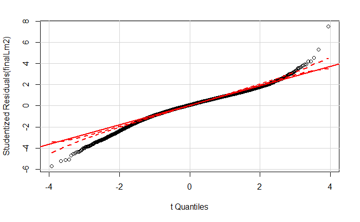

```r
library(car)
qqPlot(finalLm2)
```

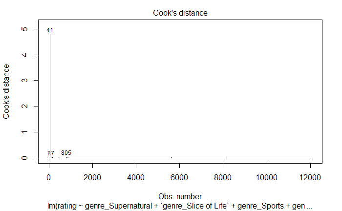

```r
plot(finalLm2,which=4)
```

```r
aniMat[c(41,87,805),]
```

|  | type | episodes | members | genre_Action | genre_Adventure | genre_Cars | genre_Comedy | genre_Dementia | genre_Demons | genre_Drama | genre_Ecchi | genre_Fantasy | genre_Game | genre_Harem | genre_Hentai | genre_Historical | genre_Horror | genre_Josei | genre_Kids | genre_Magic | genre_Martial Arts | genre_Mecha | genre_Military | genre_Music | genre_Mystery | genre_Parody | genre_Police | genre_Psychological | genre_Romance | … |
| --- | --- | --- | --- | --- | --- | --- | --- | --- | --- | --- | --- | --- | --- | --- | --- | --- | --- | --- | --- | --- | --- | --- | --- | --- | --- | --- | --- | --- | --- | --- |
| 41 | 7 | 115 | 1013917 | 0 | 0 | 0 | 0 | 0 | 0 | 0 | 0 | 0 | 0 | 0 | 0 | 0 | 0 | 0 | 0 | 0 | 0 | 0 | 0 | 0 | 1 | 0 | 1 | 1 | 0 | … |
| 87 | 7 | 88 | 896229 | 1 | 0 | 0 | 0 | 0 | 0 | 1 | 0 | 1 | 0 | 0 | 0 | 0 | 0 | 0 | 0 | 0 | 0 | 0 | 0 | 0 | 0 | 0 | 0 | 0 | 0 | … |
| 805 | 7 | 88 | 893100 | 1 | 1 | 0 | 0 | 0 | 0 | 0 | 0 | 1 | 1 | 0 | 0 | 0 | 0 | 0 | 0 | 0 | 0 | 0 | 0 | 0 | 0 | 0 | 0 | 0 | 1 | … |

We try removing these outliers and fitting the model again.

```r
finalLmWO <- lm(rating~genre_Supernatural+genre_SliceofLife+genre_Sports+genre_Shoujo+
genre_Shounen+genre_Romance+genre_School+genre_SciFi+genre_Seinen+genre_Music+genre_Mystery+
genre_Police+genre_Psychological+genre_Kids+genre_Military+genre_Hentai+genre_Historical+genre_Horror+genre_Josei+
genre_Dementia+genre_Drama+genre_Fantasy+type+episodes+genre_Action+genre_Adventure+genre_Comedy+poly(members,4), data=aniMat[-c(41,87,805),])
summary(finalLmWO)
```

```
Call:
lm(formula = rating ~ genre_Supernatural + genre_SliceofLife +
    genre_Sports + genre_Shoujo + genre_Shounen + genre_Romance +
    genre_School + genre_SciFi + genre_Seinen + genre_Music +
    genre_Mystery + genre_Police + genre_Psychological + genre_Kids +
    genre_Military + genre_Hentai + genre_Historical + genre_Horror +
    genre_Josei + genre_Dementia + genre_Drama + genre_Fantasy +
    type + episodes + genre_Action + genre_Adventure + genre_Comedy +
    poly(members, 4), data = aniMat[-c(41, 87, 805), ])

Residuals:
    Min      1Q  Median      3Q     Max
-4.4682 -0.4311  0.0589  0.5093  4.1936

Coefficients:
                      Estimate Std. Error t value Pr(>|t|)
(Intercept)          5.947e+00  2.805e-02 212.003  < 2e-16 ***
genre_Supernatural   5.858e-02  2.833e-02   2.068 0.038677 *
genre_SliceofLife    1.883e-01  2.554e-02   7.373 1.78e-13 ***
genre_Sports         2.578e-01  3.679e-02   7.009 2.52e-12 ***
genre_Shoujo         2.788e-01  3.470e-02   8.035 1.03e-15 ***
genre_Shounen        3.584e-01  2.309e-02  15.518  < 2e-16 ***
genre_Romance        3.420e-02  2.453e-02   1.394 0.163232
genre_School         1.515e-01  2.630e-02   5.762 8.54e-09 ***
genre_SciFi          1.310e-01  2.143e-02   6.111 1.02e-09 ***
genre_Seinen         1.891e-01  3.610e-02   5.239 1.65e-07 ***
genre_Music         -1.235e-01  3.003e-02  -4.112 3.95e-05 ***
genre_Mystery        3.339e-01  3.931e-02   8.493  < 2e-16 ***
genre_Police         3.936e-01  5.926e-02   6.643 3.21e-11 ***
genre_Psychological  8.364e-02  5.577e-02   1.500 0.133671
genre_Kids          -2.841e-02  2.299e-02  -1.236 0.216594
genre_Military       2.724e-01  4.126e-02   6.600 4.27e-11 ***
genre_Hentai         1.705e-01  2.864e-02   5.954 2.69e-09 ***
genre_Historical     2.975e-01  2.996e-02   9.929  < 2e-16 ***
genre_Horror        -1.970e-01  4.432e-02  -4.446 8.84e-06 ***
genre_Josei          3.966e-01  1.106e-01   3.587 0.000335 ***
genre_Dementia      -8.763e-01  5.361e-02 -16.345  < 2e-16 ***
genre_Drama          3.869e-01  2.093e-02  18.485  < 2e-16 ***
genre_Fantasy        1.515e-01  2.016e-02   7.518 5.97e-14 ***
type                 2.159e-02  4.788e-03   4.510 6.55e-06 ***
episodes             1.550e-03  1.533e-04  10.111  < 2e-16 ***
genre_Action         3.936e-02  1.958e-02   2.010 0.044458 *
genre_Adventure      1.976e-01  2.019e-02   9.786  < 2e-16 ***
genre_Comedy         7.504e-02  1.691e-02   4.436 9.24e-06 ***
poly(members, 4)1    3.581e+01  8.849e-01  40.471  < 2e-16 ***
poly(members, 4)2   -2.318e+01  8.326e-01 -27.846  < 2e-16 ***
poly(members, 4)3    1.726e+01  8.114e-01  21.272  < 2e-16 ***
poly(members, 4)4   -1.429e+01  7.997e-01 -17.866  < 2e-16 ***
---
Signif. codes:  0 *** 0.001 ** 0.01 * 0.05 . 0.1   1

Residual standard error: 0.786 on 12029 degrees of freedom
Multiple R-squared:  0.4151,    Adjusted R-squared:  0.4136
F-statistic: 275.4 on 31 and 12029 DF,  p-value: < 2.2e-16
```

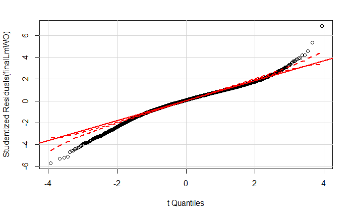

```r
qqPlot(finalLmWO)
```

check for homoskedasticity

```r
library(car)
ncvTest(finalLm2)
```

```
Non-constant Variance Score Test
Variance formula: ~ fitted.values
Chisquare = 421.3095    Df = 1     p = 1.26596e-93
```

```r
ncvTest(finalLmWO)
```

```
Non-constant Variance Score Test
Variance formula: ~ fitted.values
Chisquare = 412.9406    Df = 1     p = 8.395498e-92
```

```r
boot.fn <- function(data,index){
tempLm <- lm(rating~genre_Supernatural+`genre_Slice of Life`+genre_Sports+genre_Shoujo+
genre_Shounen+genre_Romance+genre_School+`genre_Sci-Fi`+genre_Seinen+genre_Music+genre_Mystery+
genre_Police+genre_Psychological+genre_Kids+genre_Military+genre_Hentai+genre_Historical+genre_Horror+genre_Josei+
genre_Dementia+genre_Drama+genre_Fantasy+type+episodes+genre_Action+genre_Adventure+genre_Comedy+poly(members,4),data=data,subset=index)
tempCoef <- coef(tempLm)
return(tempCoef)
}
boot(aniMat,boot.fn,R=1000)
```

```
ORDINARY NONPARAMETRIC BOOTSTRAP


Call:
boot(data = aniMat, statistic = boot.fn, R = 1000)


Bootstrap Statistics :
          original        bias     std. error
t1*    5.931679832  1.989480e-03 0.0317580724
t2*    0.073233024 -4.324779e-03 0.0257386456
t3*    0.192211725 -1.925923e-03 0.0258029263
t4*    0.260067650 -2.618708e-03 0.0346938000
t5*    0.280909335 -2.288983e-03 0.0287160789
t6*    0.361629138  7.496048e-05 0.0211468490
t7*    0.039801595  5.592514e-04 0.0211922957
t8*    0.154942461  6.273221e-04 0.0223758649
t9*    0.135316866 -2.298732e-05 0.0205005236
t10*   0.195995440 -1.984753e-03 0.0300352721
t11*  -0.122772595 -5.949059e-05 0.0336573915
t12*   0.341407509 -1.117430e-03 0.0345788545
t13*   0.413107269 -6.226139e-03 0.0495265547
t14*   0.114944944 -1.166505e-02 0.0594092934
t15*  -0.039156539  2.736876e-03 0.0268612732
t16*   0.266843123 -1.163593e-04 0.0382652581
t17*   0.169483246  9.496681e-05 0.0266688317
t18*   0.295974737 -1.035171e-03 0.0331206647
t19*  -0.196523391  8.054132e-04 0.0478631077
t20*   0.409550238  1.959939e-03 0.0923338975
t21*  -0.881886060  1.073637e-03 0.0654775088
t22*   0.390549239 -1.168278e-03 0.0209852057
t23*   0.155399903 -3.878583e-04 0.0194957964
t24*   0.023177844 -6.227273e-06 0.0051611936
t25*   0.001530886 -1.888956e-06 0.0001608363
t26*   0.044325428 -1.881995e-03 0.0188240163
t27*   0.198112717 -8.581667e-04 0.0190893490
t28*   0.080429476 -1.792179e-03 0.0167235109
t29*  34.714363997 -1.058180e+00 3.4029523250
t30* -22.342849903 -2.941187e+00 8.0527158241
t31*  16.460820576 -3.466297e+00 8.9002292646
t32* -14.639028159 -2.747933e+00 5.6627975839
```

Splines

```r
library(mgcv)
library(gamclass)
library(ggplot2)
```

```r
aniMat = as.data.frame(aniMat)
gam.a<- gam(rating~genre_Supernatural+genre_SliceofLife +genre_Sports+genre_Shoujo+
genre_Shounen+genre_Romance+genre_School+genre_SciFi+genre_Seinen+genre_Music+genre_Mystery+
genre_Police+genre_Psychological+genre_Kids+genre_Military+genre_Hentai+genre_Historical+genre_Horror+genre_Josei+
genre_Dementia+genre_Drama+genre_Fantasy+type+episodes+genre_Action+genre_Adventure+genre_Comedy+s(members), data = aniMat)
summary(gam.a)
```

```
Family: gaussian
Link function: identity

Formula:
rating ~ genre_Supernatural + genre_SliceofLife + genre_Sports +
    genre_Shoujo + genre_Shounen + genre_Romance + genre_School +
    genre_SciFi + genre_Seinen + genre_Music + genre_Mystery +
    genre_Police + genre_Psychological + genre_Kids + genre_Military +
    genre_Hentai + genre_Historical + genre_Horror + genre_Josei +
    genre_Dementia + genre_Drama + genre_Fantasy + type + episodes +
    genre_Action + genre_Adventure + genre_Comedy + s(members)

Parametric coefficients:
                      Estimate Std. Error t value Pr(>|t|)
(Intercept)          6.0258986  0.0273756 220.119  < 2e-16 ***
genre_Supernatural   0.0481628  0.0274983   1.751  0.07989 .
genre_SliceofLife    0.1666363  0.0247981   6.720 1.90e-11 ***
genre_Sports         0.2515330  0.0356950   7.047 1.93e-12 ***
genre_Shoujo         0.2653142  0.0336742   7.879 3.59e-15 ***
genre_Shounen        0.3183614  0.0224591  14.175  < 2e-16 ***
genre_Romance       -0.0111367  0.0238532  -0.467  0.64059
genre_School         0.1080048  0.0255741   4.223 2.43e-05 ***
genre_SciFi          0.1147653  0.0208091   5.515 3.56e-08 ***
genre_Seinen         0.1586201  0.0350513   4.525 6.09e-06 ***
genre_Music         -0.1232298  0.0291435  -4.228 2.37e-05 ***
genre_Mystery        0.3063461  0.0381668   8.027 1.10e-15 ***
genre_Police         0.3396879  0.0575285   5.905 3.63e-09 ***
genre_Psychological  0.0653391  0.0540898   1.208  0.22708
genre_Kids           0.0393452  0.0224440   1.753  0.07962 .
genre_Military       0.2215849  0.0400620   5.531 3.25e-08 ***
genre_Hentai         0.1608773  0.0277950   5.788 7.30e-09 ***
genre_Historical     0.3170508  0.0290872  10.900  < 2e-16 ***
genre_Horror        -0.2063998  0.0430020  -4.800 1.61e-06 ***
genre_Josei          0.3446160  0.1073076   3.211  0.00132 **
genre_Dementia      -0.8613747  0.0520277 -16.556  < 2e-16 ***
genre_Drama          0.3609032  0.0203272  17.755  < 2e-16 ***
genre_Fantasy        0.1228483  0.0195964   6.269 3.76e-10 ***
type                 0.0149247  0.0046522   3.208  0.00134 **
episodes             0.0015435  0.0001488  10.372  < 2e-16 ***
genre_Action         0.0190059  0.0190145   1.000  0.31755
genre_Adventure      0.1862419  0.0195949   9.505  < 2e-16 ***
genre_Comedy         0.0479680  0.0164460   2.917  0.00354 **
---
Signif. codes:  0 *** 0.001 ** 0.01 * 0.05 . 0.1   1

Approximate significance of smooth terms:
             edf Ref.df     F p-value
s(members) 8.973      9 386.2  <2e-16 ***
---
Signif. codes:  0 *** 0.001 ** 0.01 * 0.05 . 0.1   1

R-sq.(adj) =  0.448   Deviance explained =   45%
GCV = 0.58345  Scale est. = 0.58167   n = 12064
```

```r
CVgam(formula(gam.a),aniMat,nfold=10)
```

```
   GAMscale CV-mse-GAM
     0.5817      0.5822
```

```r
anova(finalLm2,gam.a,test="F")
```

```
Analysis of Variance Table

Model 1: rating ~ genre_Supernatural + genre_SliceofLife + genre_Sports +
    genre_Shoujo + genre_Shounen + genre_Romance + genre_School +
    genre_SciFi + genre_Seinen + genre_Music + genre_Mystery +
    genre_Police + genre_Psychological + genre_Kids + genre_Military +
    genre_Hentai + genre_Historical + genre_Horror + genre_Josei +
    genre_Dementia + genre_Drama + genre_Fantasy + type + episodes +
    genre_Action + genre_Adventure + genre_Comedy + poly(members,
    4)
Model 2: rating ~ genre_Supernatural + genre_SliceofLife + genre_Sports +
    genre_Shoujo + genre_Shounen + genre_Romance + genre_School +
    genre_SciFi + genre_Seinen + genre_Music + genre_Mystery +
    genre_Police + genre_Psychological + genre_Kids + genre_Military +
    genre_Hentai + genre_Historical + genre_Horror + genre_Josei +
    genre_Dementia + genre_Drama + genre_Fantasy + type + episodes +
    genre_Action + genre_Adventure + genre_Comedy + s(members)
  Res.Df    RSS     Df Sum of Sq      F    Pr(>F)
1  12032 7509.7
2  12027 6995.7 4.9726    514.01 177.71 < 2.2e-16 ***
---
Signif. codes:  0 *** 0.001 ** 0.01 * 0.05 . 0.1   1
```

MSE becomes 0.5822 now. Try add spline on episodes.

```r
gam.a2<- gam(rating~genre_Supernatural+genre_SliceofLife +genre_Sports+genre_Shoujo+
genre_Shounen+genre_Romance+genre_School+genre_SciFi+genre_Seinen+genre_Music+genre_Mystery+
genre_Police+genre_Psychological+genre_Kids+genre_Military+genre_Hentai+genre_Historical+genre_Horror+genre_Josei+
genre_Dementia+genre_Drama+genre_Fantasy+type+s(episodes)+genre_Action+genre_Adventure+genre_Comedy+s(members), data = aniMat)
summary(gam.a2)
```

```
Family: gaussian
Link function: identity

Formula:
rating ~ genre_Supernatural + genre_SliceofLife + genre_Sports +
    genre_Shoujo + genre_Shounen + genre_Romance + genre_School +
    genre_SciFi + genre_Seinen + genre_Music + genre_Mystery +
    genre_Police + genre_Psychological + genre_Kids + genre_Military +
    genre_Hentai + genre_Historical + genre_Horror + genre_Josei +
    genre_Dementia + genre_Drama + genre_Fantasy + type + s(episodes) +
    genre_Action + genre_Adventure + genre_Comedy + s(members)

Parametric coefficients:
                     Estimate Std. Error t value Pr(>|t|)
(Intercept)          6.045933   0.031985 189.025  < 2e-16 ***
genre_Supernatural   0.050991   0.027352   1.864 0.062315 .
genre_SliceofLife    0.176177   0.024700   7.133 1.04e-12 ***
genre_Sports         0.243250   0.035519   6.848 7.83e-12 ***
genre_Shoujo         0.244909   0.033547   7.300 3.05e-13 ***
genre_Shounen        0.302219   0.022387  13.500  < 2e-16 ***
genre_Romance       -0.016320   0.023749  -0.687 0.491989
genre_School         0.118363   0.025465   4.648 3.39e-06 ***
genre_SciFi          0.112089   0.020723   5.409 6.46e-08 ***
genre_Seinen         0.163554   0.034881   4.689 2.78e-06 ***
genre_Music         -0.124475   0.028998  -4.293 1.78e-05 ***
genre_Mystery        0.297109   0.037980   7.823 5.60e-15 ***
genre_Police         0.335989   0.057209   5.873 4.39e-09 ***
genre_Psychological  0.058677   0.053808   1.090 0.275522
genre_Kids           0.033049   0.022405   1.475 0.140216
genre_Military       0.217142   0.039844   5.450 5.14e-08 ***
genre_Hentai         0.154329   0.028940   5.333 9.85e-08 ***
genre_Historical     0.313744   0.028932  10.844  < 2e-16 ***
genre_Horror        -0.208798   0.042789  -4.880 1.08e-06 ***
genre_Josei          0.341512   0.106760   3.199 0.001383 **
genre_Dementia      -0.861532   0.051771 -16.641  < 2e-16 ***
genre_Drama          0.351807   0.020238  17.384  < 2e-16 ***
genre_Fantasy        0.119269   0.019492   6.119 9.71e-10 ***
type                 0.026458   0.005342   4.953 7.40e-07 ***
genre_Action         0.012874   0.018924   0.680 0.496305
genre_Adventure      0.175048   0.019530   8.963  < 2e-16 ***
genre_Comedy         0.054333   0.016385   3.316 0.000916 ***
---
Signif. codes:  0 *** 0.001 ** 0.01 * 0.05 . 0.1   1

Approximate significance of smooth terms:
              edf Ref.df      F p-value
s(episodes) 8.771  8.983  28.18  <2e-16 ***
s(members)  8.974  9.000 388.71  <2e-16 ***
---
Signif. codes:  0 *** 0.001 ** 0.01 * 0.05 . 0.1   1

R-sq.(adj) =  0.455   Deviance explained = 45.6%
GCV = 0.5772  Scale est. = 0.57506   n = 12064
```

```r
CVgam(formula(gam.a2),aniMat,nfold=10)
```

```
   GAMscale CV-mse-GAM
     0.5751      0.5761
```

```r
anova(gam.a,gam.a2,test="F")
```

```
Analysis of Deviance Table

Model 1: rating ~ genre_Supernatural + genre_SliceofLife + genre_Sports +
    genre_Shoujo + genre_Shounen + genre_Romance + genre_School +
    genre_SciFi + genre_Seinen + genre_Music + genre_Mystery +
    genre_Police + genre_Psychological + genre_Kids + genre_Military +
    genre_Hentai + genre_Historical + genre_Horror + genre_Josei +
    genre_Dementia + genre_Drama + genre_Fantasy + type + episodes +
    genre_Action + genre_Adventure + genre_Comedy + s(members)
Model 2: rating ~ genre_Supernatural + genre_SliceofLife + genre_Sports +
    genre_Shoujo + genre_Shounen + genre_Romance + genre_School +
    genre_SciFi + genre_Seinen + genre_Music + genre_Mystery +
    genre_Police + genre_Psychological + genre_Kids + genre_Military +
    genre_Hentai + genre_Historical + genre_Horror + genre_Josei +
    genre_Dementia + genre_Drama + genre_Fantasy + type + s(episodes) +
    genre_Action + genre_Adventure + genre_Comedy + s(members)
  Resid. Df Resid. Dev     Df Deviance      F    Pr(>F)
1     12027     6995.7
2     12019     6911.8 7.9829   83.902 18.277 < 2.2e-16 ***
---
Signif. codes:  0 *** 0.001 ** 0.01 * 0.05 . 0.1   1
```

MSE becomes 0.5761 now.

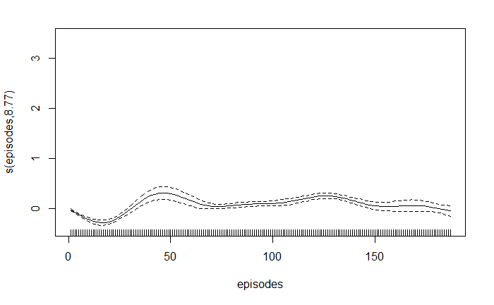

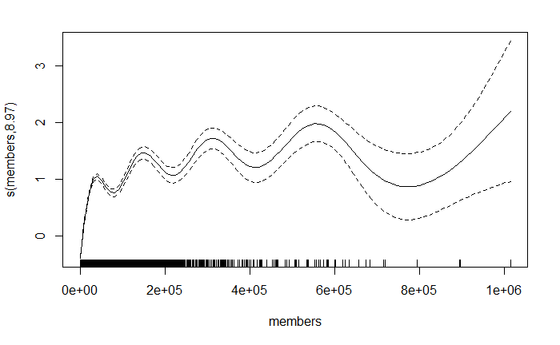

```r
plot(gam.a2)
```

```r
memList <- list()
memList[[1]] <- gam(rating ~ genre_Supernatural + genre_SliceofLife + genre_Sports +
    genre_Shoujo + genre_Shounen + genre_Romance + genre_School +
    genre_SciFi + genre_Seinen + genre_Music + genre_Mystery +
    genre_Police + genre_Psychological + genre_Kids + genre_Military +
    genre_Hentai + genre_Historical + genre_Horror + genre_Josei +
    genre_Dementia + genre_Drama + genre_Fantasy + type + s(episodes) +
    genre_Action + genre_Adventure + genre_Comedy + members,data=aniMat)
for(i in 2:10){
memList[[i]] <- gam(rating ~ genre_Supernatural + genre_SliceofLife + genre_Sports +
    genre_Shoujo + genre_Shounen + genre_Romance + genre_School +
    genre_SciFi + genre_Seinen + genre_Music + genre_Mystery +
    genre_Police + genre_Psychological + genre_Kids + genre_Military +
    genre_Hentai + genre_Historical + genre_Horror + genre_Josei +
    genre_Dementia + genre_Drama + genre_Fantasy + type + s(episodes) +
    genre_Action + genre_Adventure + genre_Comedy + s(members,k=i+1),data=aniMat)
}
memMSE <- rep(0,10)
for(i in 1:10){
memMSE[i] <- CVgam(formula(memList[[i]]),aniMat)$cvscale
}
```

```
   GAMscale CV-mse-GAM
     0.6885      0.6911
   GAMscale CV-mse-GAM
     0.6593      0.6610
   GAMscale CV-mse-GAM
     0.6397      0.6417
   GAMscale CV-mse-GAM
     0.6228      0.6239
   GAMscale CV-mse-GAM
     0.6097      0.6105
   GAMscale CV-mse-GAM
     0.5981      0.5994
   GAMscale CV-mse-GAM
     0.5877      0.5896
   GAMscale CV-mse-GAM
     0.5803      0.5820
   GAMscale CV-mse-GAM
     0.5751      0.5761
   GAMscale CV-mse-GAM
     0.5665      0.5683
```

```r
gam.a2.final<- gam(rating~genre_Supernatural+genre_SliceofLife +genre_Sports+genre_Shoujo+
genre_Shounen+genre_Romance+genre_School+genre_SciFi+genre_Seinen+genre_Music+genre_Mystery+
genre_Police+genre_Psychological+genre_Kids+genre_Military+genre_Hentai+genre_Historical+genre_Horror+genre_Josei+
genre_Dementia+genre_Drama+genre_Fantasy+type+s(episodes)+genre_Action+genre_Adventure+genre_Comedy+s(members,k=10), data = aniMat)
summary(gam.a2.final)
```

```
Family: gaussian
Link function: identity

Formula:
rating ~ genre_Supernatural + genre_SliceofLife + genre_Sports +
    genre_Shoujo + genre_Shounen + genre_Romance + genre_School +
    genre_SciFi + genre_Seinen + genre_Music + genre_Mystery +
    genre_Police + genre_Psychological + genre_Kids + genre_Military +
    genre_Hentai + genre_Historical + genre_Horror + genre_Josei +
    genre_Dementia + genre_Drama + genre_Fantasy + type + s(episodes) +
    genre_Action + genre_Adventure + genre_Comedy + s(members,
    k = 10)

Parametric coefficients:
                     Estimate Std. Error t value Pr(>|t|)
(Intercept)          6.045933   0.031985 189.025  < 2e-16 ***
genre_Supernatural   0.050991   0.027352   1.864 0.062315 .
genre_SliceofLife    0.176177   0.024700   7.133 1.04e-12 ***
genre_Sports         0.243250   0.035519   6.848 7.83e-12 ***
genre_Shoujo         0.244909   0.033547   7.300 3.05e-13 ***
genre_Shounen        0.302219   0.022387  13.500  < 2e-16 ***
genre_Romance       -0.016320   0.023749  -0.687 0.491989
genre_School         0.118363   0.025465   4.648 3.39e-06 ***
genre_SciFi          0.112089   0.020723   5.409 6.46e-08 ***
genre_Seinen         0.163554   0.034881   4.689 2.78e-06 ***
genre_Music         -0.124475   0.028998  -4.293 1.78e-05 ***
genre_Mystery        0.297109   0.037980   7.823 5.60e-15 ***
genre_Police         0.335989   0.057209   5.873 4.39e-09 ***
genre_Psychological  0.058677   0.053808   1.090 0.275522
genre_Kids           0.033049   0.022405   1.475 0.140216
genre_Military       0.217142   0.039844   5.450 5.14e-08 ***
genre_Hentai         0.154329   0.028940   5.333 9.85e-08 ***
genre_Historical     0.313744   0.028932  10.844  < 2e-16 ***
genre_Horror        -0.208798   0.042789  -4.880 1.08e-06 ***
genre_Josei          0.341512   0.106760   3.199 0.001383 **
genre_Dementia      -0.861532   0.051771 -16.641  < 2e-16 ***
genre_Drama          0.351807   0.020238  17.384  < 2e-16 ***
genre_Fantasy        0.119269   0.019492   6.119 9.71e-10 ***
type                 0.026458   0.005342   4.953 7.40e-07 ***
genre_Action         0.012874   0.018924   0.680 0.496305
genre_Adventure      0.175048   0.019530   8.963  < 2e-16 ***
genre_Comedy         0.054333   0.016385   3.316 0.000916 ***
---
Signif. codes:  0 *** 0.001 ** 0.01 * 0.05 . 0.1   1

Approximate significance of smooth terms:
              edf Ref.df      F p-value
s(episodes) 8.771  8.983  28.18  <2e-16 ***
s(members)  8.974  9.000 388.71  <2e-16 ***
---
Signif. codes:  0 *** 0.001 ** 0.01 * 0.05 . 0.1   1

R-sq.(adj) =  0.455   Deviance explained = 45.6%
GCV = 0.5772  Scale est. = 0.57506   n = 12064
```

```r
CVgam(formula(gam.a2.final),aniMat,nfold=10)
```

```
   GAMscale CV-mse-GAM
     0.5751      0.5761
```

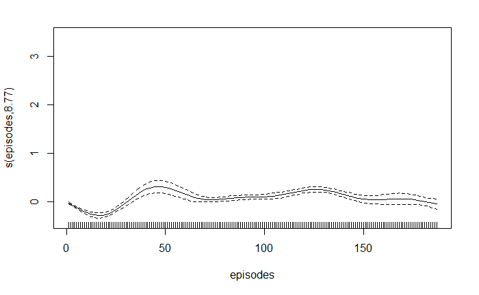

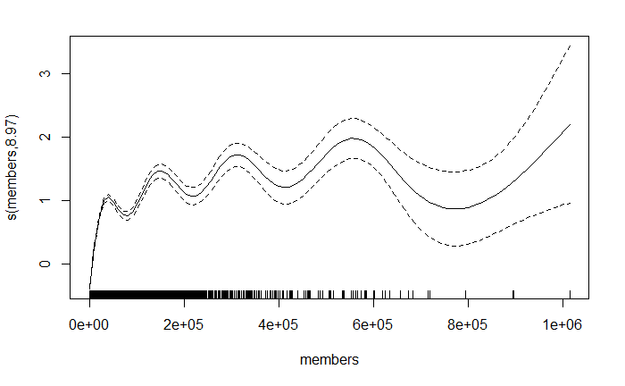

```r
plot(gam.a2.final)
```

Interaction terms Remember that type and episodes had 45% correlation.

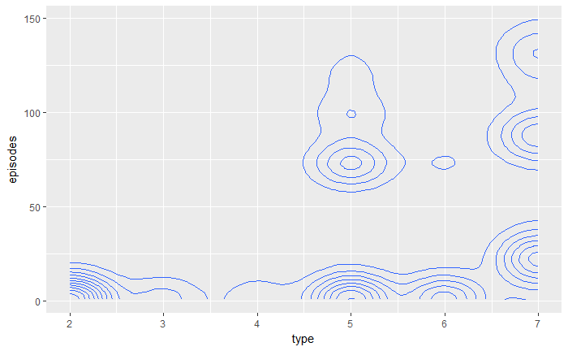

```r
ggplot(aniMat,aes(x=type,y=episodes))+stat_density2d()
```

```r
gam.a2.final2<- gam(rating~genre_Supernatural+genre_SliceofLife +genre_Sports+genre_Shoujo+
genre_Shounen+genre_Romance+genre_School+genre_SciFi+genre_Seinen+genre_Music+genre_Mystery+
genre_Police+genre_Psychological+genre_Kids+genre_Military+genre_Hentai+genre_Historical+genre_Horror+genre_Josei+
genre_Dementia+genre_Drama+genre_Fantasy+s(episodes,type)+genre_Action+genre_Adventure+genre_Comedy+s(members,k=10), data = aniMat)
summary(gam.a2.final2)
```

```
Family: gaussian
Link function: identity

Formula:
rating ~ genre_Supernatural + genre_SliceofLife + genre_Sports +
    genre_Shoujo + genre_Shounen + genre_Romance + genre_School +
    genre_SciFi + genre_Seinen + genre_Music + genre_Mystery +
    genre_Police + genre_Psychological + genre_Kids + genre_Military +
    genre_Hentai + genre_Historical + genre_Horror + genre_Josei +
    genre_Dementia + genre_Drama + genre_Fantasy + s(episodes,
    type) + genre_Action + genre_Adventure + genre_Comedy + s(members,
    k = 10)

Parametric coefficients:
                     Estimate Std. Error t value Pr(>|t|)
(Intercept)          6.179155   0.017713 348.848  < 2e-16 ***
genre_Supernatural   0.052248   0.027232   1.919 0.055056 .
genre_SliceofLife    0.173113   0.024582   7.042 2.00e-12 ***
genre_Sports         0.226616   0.035415   6.399 1.62e-10 ***
genre_Shoujo         0.222780   0.033519   6.646 3.13e-11 ***
genre_Shounen        0.294134   0.022318  13.179  < 2e-16 ***
genre_Romance       -0.006778   0.023648  -0.287 0.774420
genre_School         0.129542   0.025360   5.108 3.30e-07 ***
genre_SciFi          0.111736   0.020626   5.417 6.17e-08 ***
genre_Seinen         0.173532   0.034726   4.997 5.90e-07 ***
genre_Music         -0.123909   0.028900  -4.288 1.82e-05 ***
genre_Mystery        0.287083   0.037794   7.596 3.28e-14 ***
genre_Police         0.339447   0.056932   5.962 2.56e-09 ***
genre_Psychological  0.055589   0.053547   1.038 0.299226
genre_Kids           0.028827   0.022414   1.286 0.198436
genre_Military       0.214079   0.039646   5.400 6.80e-08 ***
genre_Hentai         0.190983   0.029697   6.431 1.32e-10 ***
genre_Historical     0.312994   0.028807  10.865  < 2e-16 ***
genre_Horror        -0.202280   0.042593  -4.749 2.07e-06 ***
genre_Josei          0.305529   0.106434   2.871 0.004104 **
genre_Dementia      -0.874823   0.051584 -16.959  < 2e-16 ***
genre_Drama          0.350971   0.020154  17.415  < 2e-16 ***
genre_Fantasy        0.122843   0.019413   6.328 2.57e-10 ***
genre_Action         0.014910   0.018836   0.792 0.428615
genre_Adventure      0.160130   0.019547   8.192 2.83e-16 ***
genre_Comedy         0.055460   0.016321   3.398 0.000681 ***
---
Signif. codes:  0 *** 0.001 ** 0.01 * 0.05 . 0.1   1

Approximate significance of smooth terms:
                    edf Ref.df      F p-value
s(episodes,type) 26.842  28.61  16.62  <2e-16 ***
s(members)        8.979   9.00 389.50  <2e-16 ***
---
Signif. codes:  0 *** 0.001 ** 0.01 * 0.05 . 0.1   1

R-sq.(adj) =  0.461   Deviance explained = 46.3%
GCV = 0.57155  Scale est. = 0.56862   n = 12064
```

```r
CVgam(formula(gam.a2.final2),aniMat,nfold=10)
```

```
   GAMscale CV-mse-GAM
     0.5686      0.5709
```

Lower MSE 0.5709

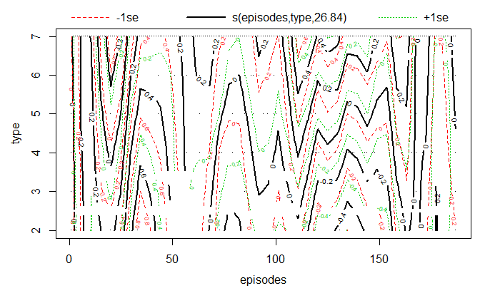

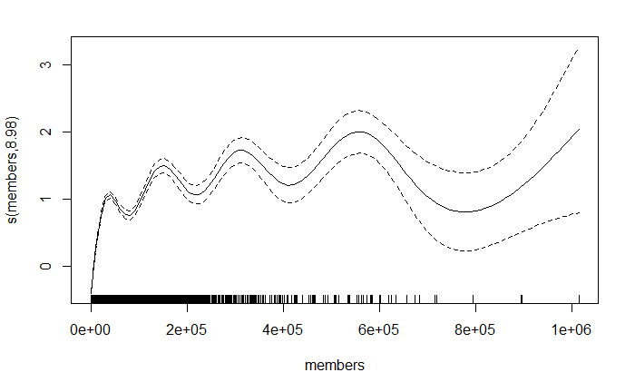

```r
plot(gam.a2.final2)
```

Extra method: Elastic Net with glnet 0

```r
en.fit = cv.glmnet(as.matrix(aniMat[,-47]),as.matrix(aniMat[,47]),family="gaussian", alpha=0.5)
min(en.fit$cvm)
```

```
[1] 0.6928732
```

Extra method:Least Angle Regression(LAR)

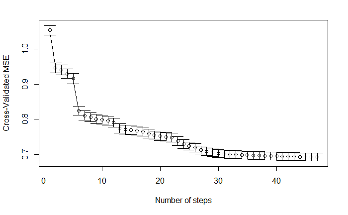

```r
#install.packages('lars')
library(lars)
mselars = cv.lars(as.matrix(aniMat[,-47]),as.matrix(aniMat[,47]),K = 10,trace = FALSE, plot.it = TRUE, se = TRUE,type = c("lar"))
```

```r
min(mselars$cv)
```

```
[1] 0.6928072
```

```r
which.min(mselars$cv)
```

```
[1] 46
```

The lost mse from LAR(0.6928072) is a little bit higher than the one I obtained with best subset selection. Huge

```r
#install.packages('huge')
library(huge)
```

```r
aniMx = as.matrix(aniMat)
huge(aniMx)
```

```
Conducting Meinshausen & Buhlmann graph estimation (mb)....done
Model: Meinshausen & Buhlmann graph estimation (mb)
Input: The Data Matrix
Path length: 10
Graph dimension: 47
Sparsity level: 0 -----> 0.2460685
```

```r
h0 = huge(aniMx)
```

```
Conducting Meinshausen & Buhlmann graph estimation (mb)....done
```

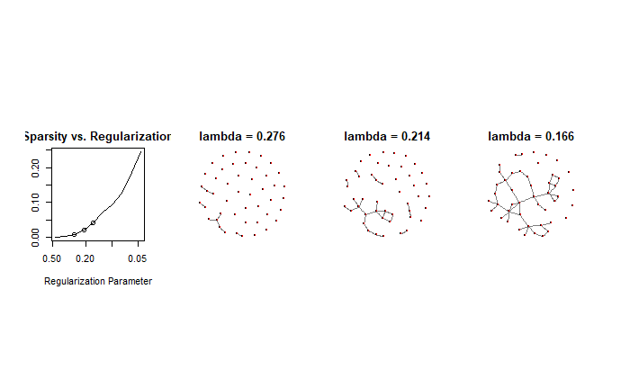

```r
plot.huge(h0)
```

```r
h1 = huge(aniMx,lambda = 0.1)
```

```
Conducting Meinshausen & Buhlmann graph estimation (mb)....done
```

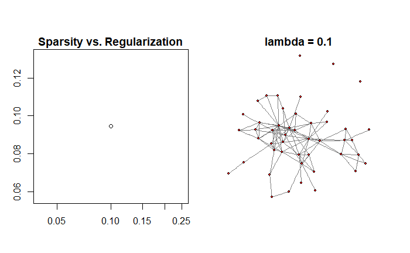

```r
plot.huge(h1)
```

```r
h2 = huge(aniMx,lambda = 0.3)
```

```
Conducting Meinshausen & Buhlmann graph estimation (mb)....done
```

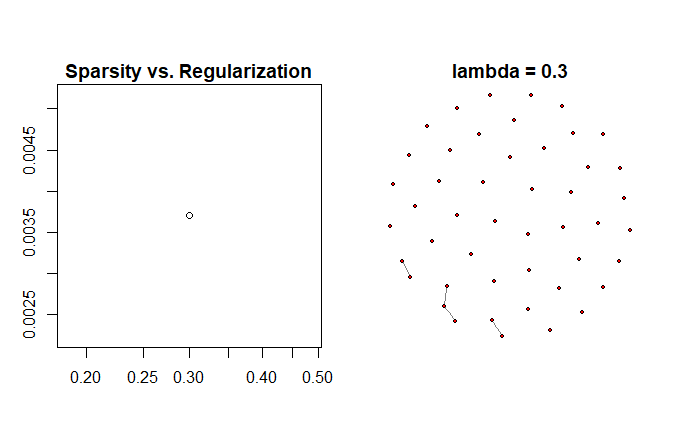

```r
plot.huge(h2)
```